# 3.5 描述分析的R语言操作

“有用的统计学”课程组

2018年10月15日

# 1 读入数据

```r
sample = read.csv("House_sample.csv", fileEncoding = "GBK")
head(sample)
```

```
##   城区 卧室数 客厅数   面积   楼层 是否靠近地铁 是否学区房   房价
## 1 朝阳      2      1  88.57    low           是         否 3.5001
## 2 朝阳      2      2  94.15 middle           是         否 6.5853
## 3 朝阳      1      0  38.01 middle           是         是 4.8672
## 4 朝阳      2      2 111.85   high           是         否 6.5266
## 5 朝阳      3      2 155.30   high           是         否 5.0870
## 6 朝阳      3      2 132.10 middle           否         否 8.3271
```

**解读与分析：** 这个数据共包括城区、卧室数、客厅数等八个变量，城区包括朝阳区、东城区、丰台区、海淀区、石景山区和西城区六个因子取值，卧室数、客厅数、面积、房价属于定量数据，楼层有高楼层、中楼层和低楼层，属于定序变量，是否靠近地铁和是否学区房是0-1变量。

# 2 用数值特征做描述：单个变量

```r
##房价基础数据统计
#install.packages("fBasics",dep=T) #需要事先安装fBasics包
library(fBasics)
basicStats(sample$房价) #对房价进行统计
```

```
##             X..sample.房价
## nobs            803.000000
## NAs               0.000000
## Minimum           1.885400
## Maximum          14.902900
## 1. Quartile       4.285950
## 3. Quartile       7.489650
## Mean              6.064605
## Median            5.734800
## Sum            4869.877800
## SE Mean           0.077623
## LCL Mean          5.912237
## UCL Mean          6.216973
## Variance          4.838322
## Stdev             2.199619
## Skewness          0.767690
## Kurtosis          0.255090
```

**解读与分析：** 定量数据可以得到中位数、平均数、四分位数，例如房价共有803个观测值，其中中位数为5.735，平均数为6.064，最小值为1.8854，最大值是14.9029，四分之一位数是4.2859，四分之三位数是7.4897；偏度为0.7677，大于零，右偏；峰度为0.255，大于零，略尖峰分布。

# 3 用统计表和统计图做描述：单个变量

## 3.1 柱形图

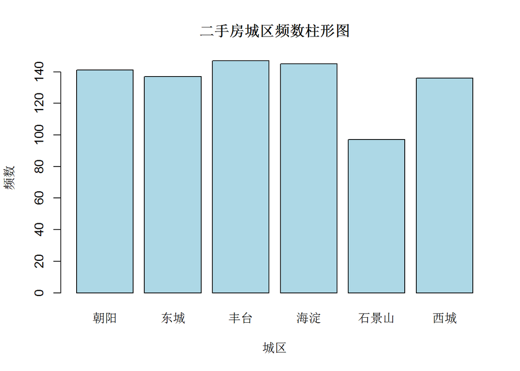

```r
fre = table(sample$城区)#频数
plot(sample$城区, xlab = "城区", ylab = "频数", col = "lightblue", main = "二手房城区频数柱形图")
```

**解读与分析：** 由图，来自丰台区的二手房最多，最少的是石景山区。

## 3.2 饼图

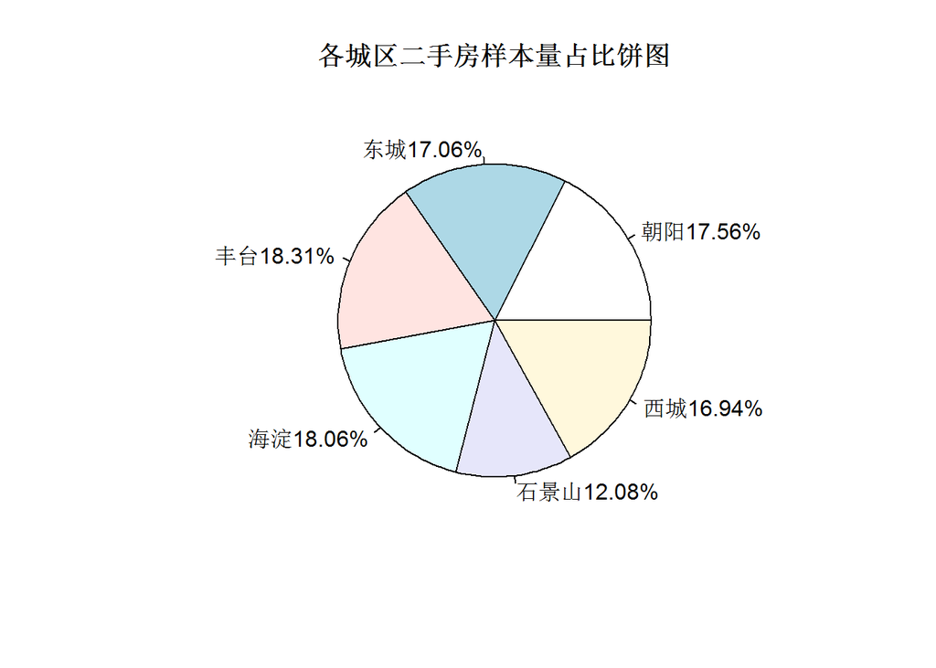

```r
lal = paste(names(fre), round(fre/sum(fre)*100, 2), "%", sep = "")#各城区占比
pie(fre, labels = lal, main = "各城区二手房样本量占比饼图")
```

**解读与分析：** 由饼图可以看出，丰台区的占比最高，达到了18.31%；石景山区最低，仅占12.08%。

## 3.3 频数分布表

```r
m = seq(0,15,by = 1)  #设置一个区间范围
table(cut(sample$房价, m)) #计算各个区间的频数
```

```
##
##   (0,1]   (1,2]   (2,3]   (3,4]   (4,5]   (5,6]   (6,7]   (7,8]   (8,9]
##       0       1      17     137     164     116     116     104      61
##  (9,10] (10,11] (11,12] (12,13] (13,14] (14,15]
##      46      18      17       2       2       2
```

**解读与分析：** 房价集中在3-8万元范围内，尤其是4-5万元的房子最多，而且数据并不是对称分布的，有少部分样本落在取值较大的区间组内，也就是存在少量的“高价房”。

## 3.4 直方图

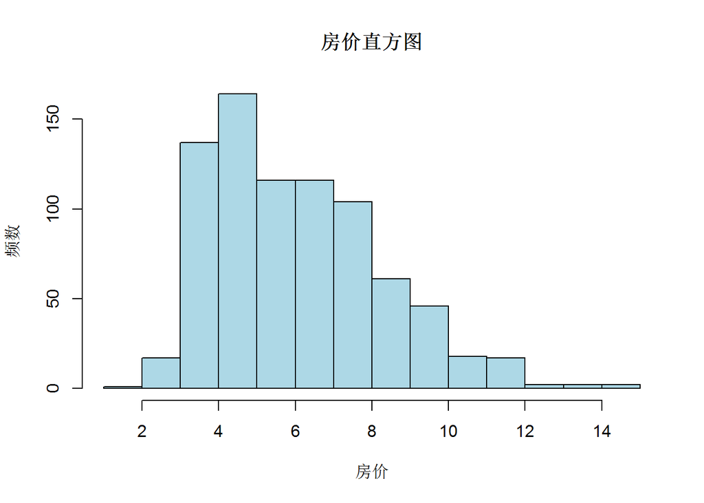

```r
hist(sample$房价, col = "lightblue",xlab = "房价",ylab = "频数",main = "房价直方图")
```

**解读与分析：** 直方图中相邻的小矩形是相互连接的、没有间隔——这是直方图与与条形图的重要区别。直方图可以直观地展示三方面的数据特征：集中趋势、离散程度和分布形态。首先，在3-8万元的区域，小矩形普遍较高，反映了二手房单价主要集中在这个区域；其次，整个直方图横跨了1-15万元的范围，数据跨度较大，说明二手房单价的离散程度较高；最后，直方图并不是对称的，尾部向右侧延伸，说明存在少数昂贵住宅、导致了数据呈现右偏分布。

## 3.5 箱线图

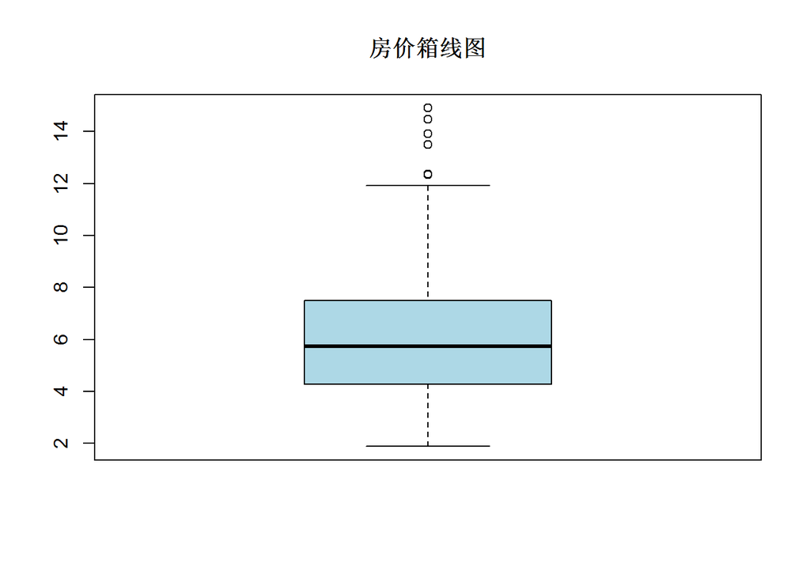

```r
boxplot(sample$房价, main = "房价箱线图",col = "lightblue")
```

**解读与分析：** 箱线图箱部代表四分之一位数到四分之三位数，中间横线代表中位数，从图中可以看出，房价有较高的离群点。

# 4 用统计表和统计图做描述：两个变量

## 4.1 列联表

```r
bar = table(sample$楼层, sample$城区)
bar
```

```
##
##          朝阳 东城 丰台 海淀 石景山 西城
##   high     46   49   65   53     37   47
##   low      46   44   45   51     21   29
##   middle   49   44   37   41     39   60
```

**解读与分析：** 城区和楼层两个定性变量，分别有6个和3个取值，列联表显示了交互后的18种取值的频数情况。

## 4.2 堆积柱形图

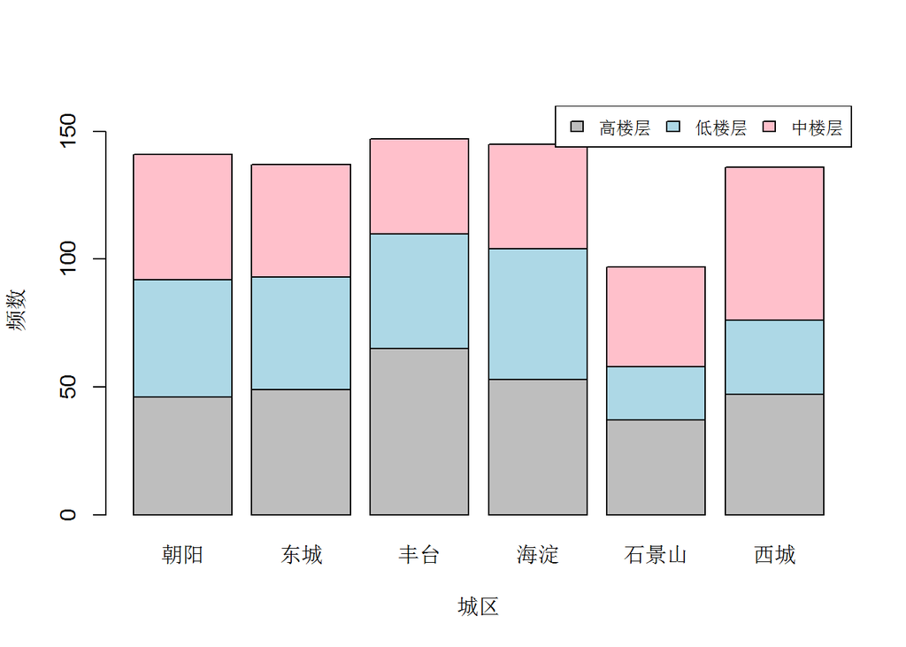

```r
barplot(bar,col = c("grey","lightblue","pink"),xlab = "城区",ylab = "频数",ylim = c(0,160))
legend("topright",c("高楼层","低楼层",'中楼层'), cex = 0.8,fill = c("grey","lightblue","pink"), ncol = 3)
```

## 4.3 比例堆积柱形图

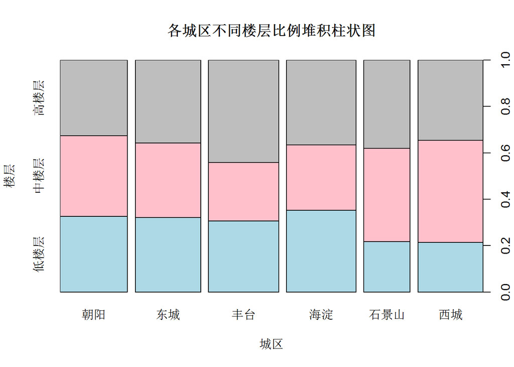

```r
spineplot(楼层 ~ 城区,data = sample,col = c("lightblue","pink","grey"),
            ylevels = c("low","middle","high"),yaxlabels = c("低楼层","中楼层","高楼层"),
            xlab = "城区",main = "各城区不同楼层比例堆积柱状图")
```

**解读与分析：** 比例堆积柱状图中,各城区柱子高度相同，海淀区低楼层占比最高；石景山区和西城区低楼层占比较小，中楼层占比较高；丰台区高楼层占比较高。

## 4.4 散点图

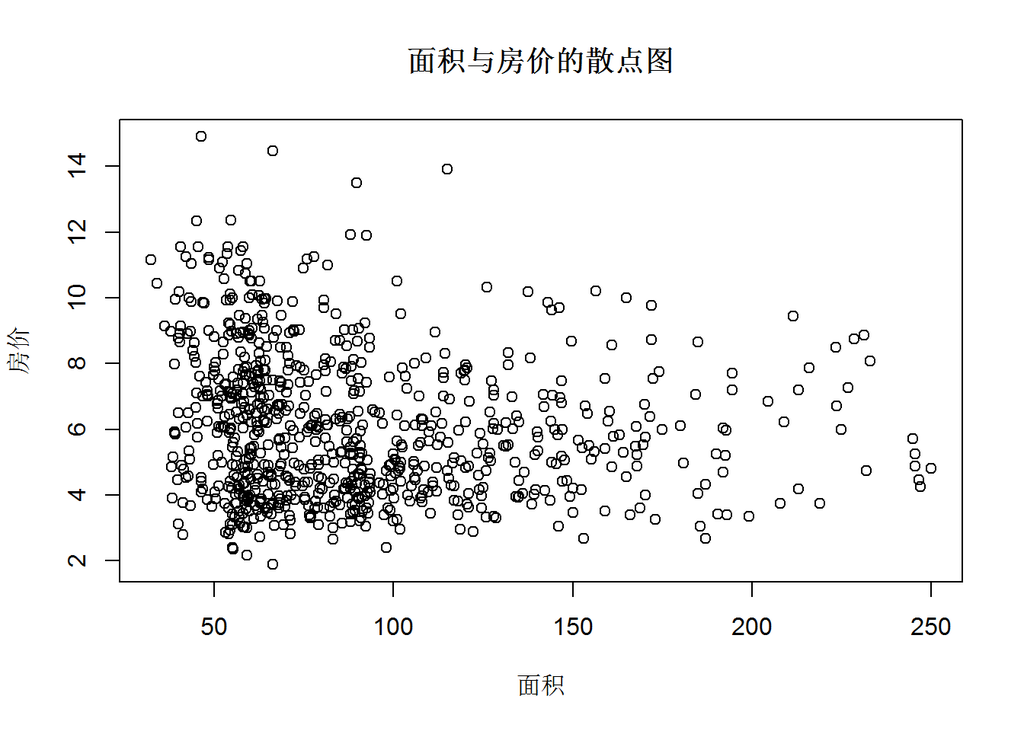

```r
plot(sample$房价 ~ sample$面积,xlab = "面积", ylab = "房价", main = "面积与房价的散点图")
```

**解读与分析：** 面积和房价呈现出负线形相关的关系，相关程度不太强，同样面积的二手房在价格上差异较大，说明还有其他的因素也对二手房价格产生了重要影响。

## 4.5 分组箱线图

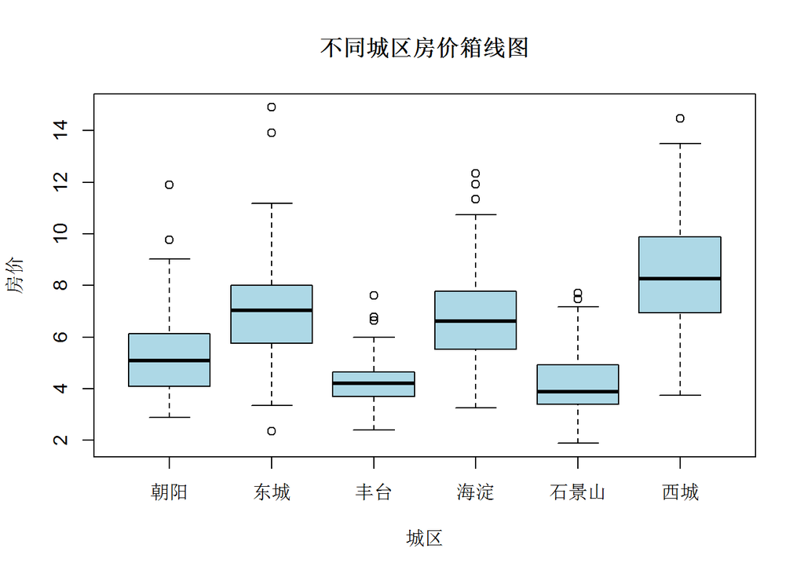

```r
boxplot(sample$房价 ~ sample$城区,col = "lightblue",xlab = "城区", ylab = "房价", main = "不同城区房价箱线图")
```

**解读与分析：** 可以看出，不同城区的房价中位数：石景山区<丰田区<朝阳区<海淀区<东城区<西城区，且丰台区的房价离散程度小，西城区离散程度较大。